# Mesurer la Biodiversité

27 novembre 2025

## Théorie

## Entropie

Expérience à plusieurs résultats possibles : espèce à laquelle appartient un individu : \(\{r_1, r_2, \dots, r_s, \dots, r_S\}\)

Probabilités associées \(\{p_1, p_2, \dots, p_s, \dots, p_S\}\)

Information \(I(p_s)\), décroissante, \(I(1) = 0\)

Entropie = Information moyenne apportée par un individu: \(\sum_s{p_s I(p_s)}\)

## Exemples

Le fondateur : Shannon (1948)

- \(I(p_s) = \ln{\frac{1}{p_s}}\)
- \(H = \sum_s{p_s \ln{\frac{1}{p_s}}}\)

Les généralisations :

- Rényi (1961) :
  - \(^{\alpha}R = \frac{1}{1 - \alpha} \ln{\sum_s{p_s^\alpha}}\)
- Tsallis (1998) :
  - \(^{q}H = \frac{1}{q - 1} (1 - \sum_s{p_s^q})\).
  - Appelée aussi HCDT (Havrda and Charvát 1967; Daróczy 1970; Tsallis 1998)

## Axiomatique

Les trois entropies respectent (Patil and Taillie 1982; Grabchak et al. 2017) :

- Symétrie
- Continuité par rapport aux probabilités
- Principe des transferts, qui contient:
  - L’ajout d’une espèce augmente la diversité
  - Maximisation si toutes les probabilités sont égales

## Propriétés

\(^{0}H\) est le nombre d’espèces -1

\(^{1}H\) est l’entropie de Shannon

\(^{2}H\) est l’entropie de Simpson : \(1 - \sum_s{p_s^2}\)

\(q\) paramétrise l’importance des espèces rares.

Application à la relation diversité-productivité en forêt Liang et al. (2016) : \(q = 2\).

## Logarithmes déformés

Tsallis (1994):

- \(\ln_q{x} = \frac{x^{1-q} - 1}{1 - q}\)
- \(e_q^x = \left[1 + \left(1 - q \right)x \right]^{\frac{1}{q - 1}}\)

Simplifie l’écriture de l’entropie HCDT (Marcon et al. 2014) :

\(^{q}H = \sum_s{p_s \ln_q{\frac{1}{p_s}}}\)

## Logarithmes déformés

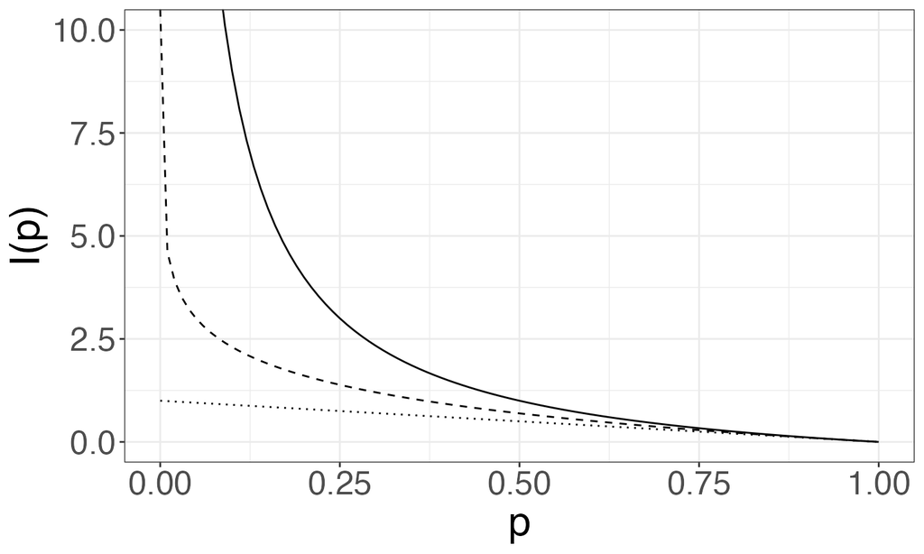

## Résumé / Définitions

La rareté est l’inverse de la probabilité : \(\frac{1}{p_s}\)

L’information est le logarithme (déformé) de la rareté : \(\ln_q{\frac{1}{p_s}}\)

L’entropie est l’espérance de l’information :

\[^{q}H = \sum_s{p_s \ln_q{\frac{1}{p_s}}}\]

## Nombres de Hill

Hill (1973) : Nombre d’espèces équiprobables ayant l’entropie des données. Nombre effectif (Wright 1931; Gregorius 1991).

Résume la diversité à un seul nombre : diversité au sens strict (Jost 2006)

La diversité est l’exponentielle de l’entropie (Marcon et al. 2014) :

\[^{q}D = e_q^{^{q}H}\]

## Pratique

## Barro Colorado Island

Diagramme rang-abondance (Whittaker 1965)

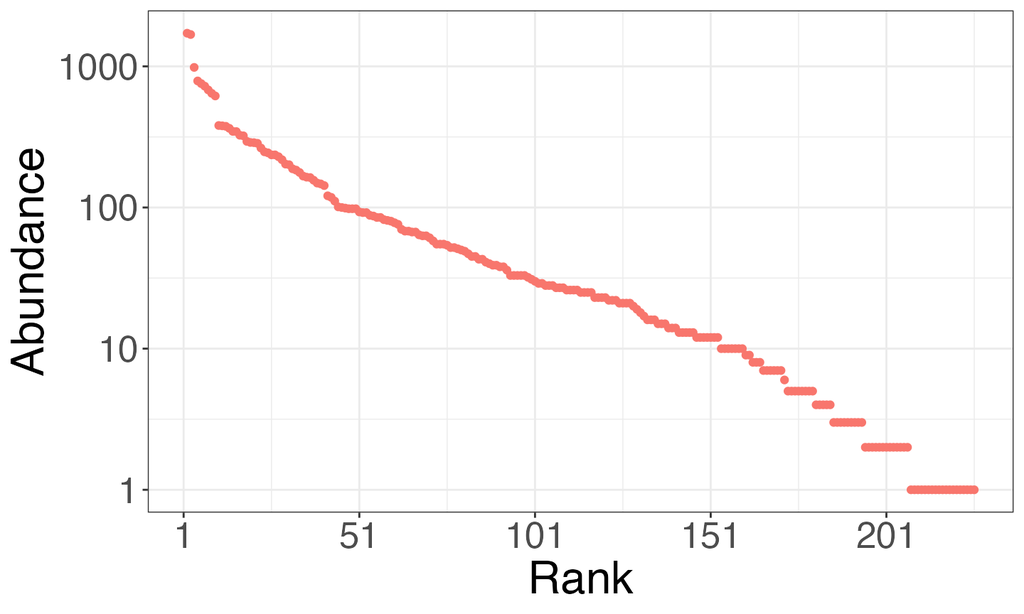

## Courbe d’accumulation

Diversité de l’échantillon, asymptotique ou standardisée

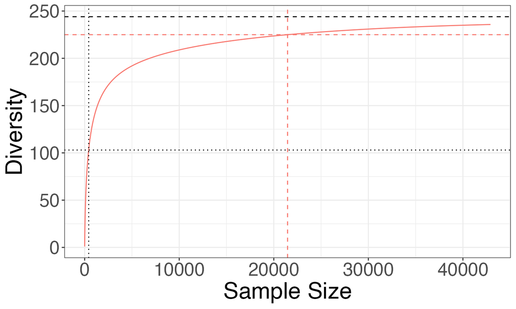

## Diversité asymptotique

Il existe des estimateurs :

- Richesse : Chao (Chao 1984) ou Jacknife (Burnham and Overton 1978)

```r
library("divent")
div_richness(BCI_50ha)
```

```
## # A tibble: 1 × 3
##   estimator   order diversity
##   <chr>       <dbl>     <dbl>
## 1 Jackknife 1     0       244
```

- Entropie HCDT :
  - Réduction du biais d’estimation (Chao and Jost 2015)
  - Estimation de la distribution réelle (Chao et al. 2015)

```r
div_hill(BCI_50ha, q = 1)
```

```
## # A tibble: 1 × 3
##   estimator order diversity
##   <chr>     <dbl>     <dbl>
## 1 UnveilJ       1      72.0
```

## Profil de diversité

Diversité en fonction de son ordre (Tothmeresz 1995)

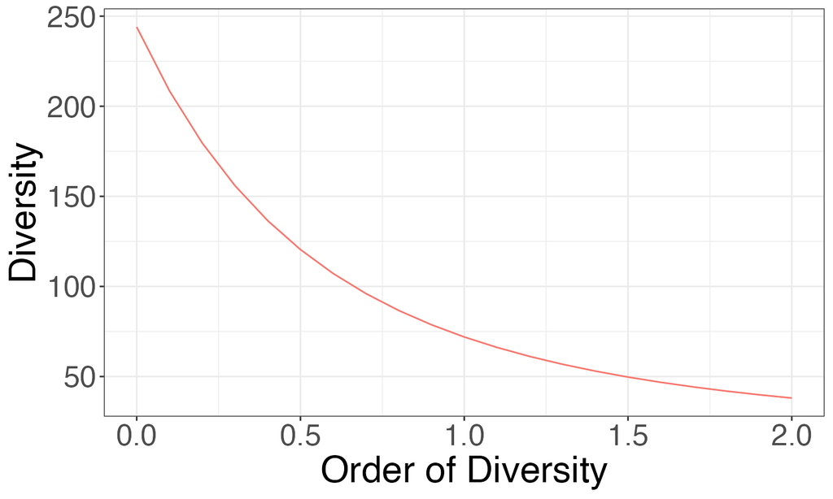

## Diversité phylogénétique

## Dendrogramme

Phylogénie dans l’idéal, taxonomie possible (Ricotta et al. 2012).

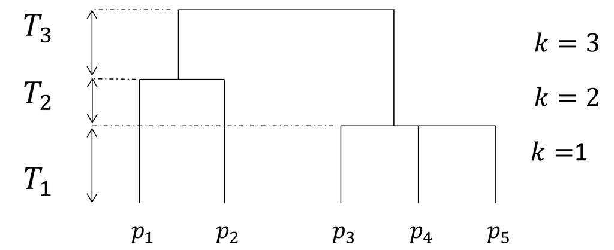

## Définition

L’entropie est l’information moyenne au cours du temps (Pavoine and Bonsall 2011).

\[^{q}\bar{H}(T) = \sum_k{\frac{T_k}{T} {^{q}_{k}H}}\] La diversité est son exponentielle (Marcon and Hérault 2015).

## Décomposition de la diversité

## Définitions

Whittaker (1960) : plusieurs communautés regroupées dans une métacommunauté dont les communautés sont des échantillons. La diversité est la richesse (entropie et diversité).

- Diversité \(\alpha\) : diversité moyenne des communautés (nombre moyen d’espèces)
- Diversité \(\gamma\) : de la métacommunauté (nombre total d’espèces)
- Diversité \(\beta\) : entre les communautés. Ratio \(\gamma / \alpha\) ou différence \(\gamma - \alpha\) (Lande 1996)

## Définitions

Précisément :

- L’entropie \(\alpha\) est la moyenne des entropies locales : quantité d’information
- La diversité est l’exponentielle de l’entropie
- La diversité \(\beta\) est le rapport des diversités, l’entropie \(\beta\) la différence des entropies
- La diversité \(\beta\) est un nombre effectif de communautés : communautés de même poids, sans aucune espèce commune (Jost 2007)

## Exemple simple

3 Communautés avec respectivement 6, 4 et 5 espèces ; 10 espèces au total :

- Diversité \(\alpha\) : 5 espèces par communauté
- Diversité \(\gamma\) : 10 espèces
- Diversité \(\beta\) : 2 communautés effectives

10 espèces = 5 espèces par communauté X 2 communautés

## BCI

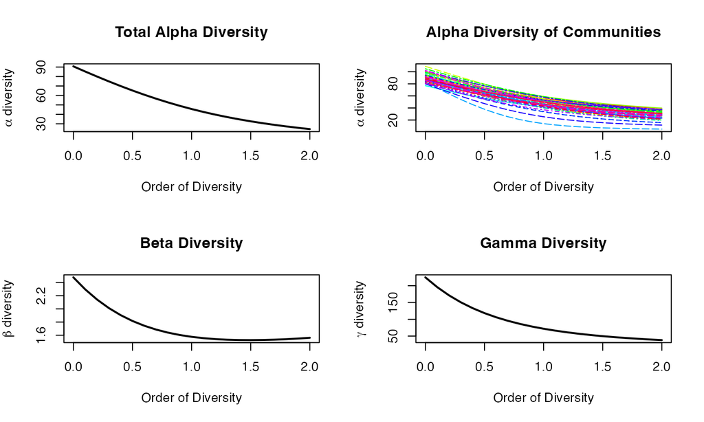

## Conclusion

## Messages à emporter

L’entropie permet de caractériser la diversité : c’est l’espérance de l’information apportée par un individu

L’entropie est une quantité d’information

La diversité au sens strict est un nombre effectif (d’espèces, de communautés…)

Pas d’indices de diversité ici : seulement des mesures

## Messages à emporter

La rareté est l’inverse de la probabilité : \(\frac{1}{p_s}\)

L’information est le logarithme (déformé) de la rareté : \(\ln_q{\frac{1}{p_s}}\)

L’entropie est l’espérance de l’information :

\[^{q}H = \sum_s{p_s \ln_q{\frac{1}{p_s}}}\]

La diversité est son exponentielle : \[^{q}D = e_q^{^{q}H}\]

En pratique : package [divent](https://ericmarcon.github.io/divent/) et de la lecture ([écran](https://ericmarcon.github.io/MesuresBioDiv2) ou [PDF](https://ericmarcon.github.io/MesuresBioDiv2/MesuresBD.pdf)).

## References

Burnham, K. P., and W. S. Overton. 1978. “Estimation of the Size of a Closed Population When Capture Probabilities Vary Among Animals.” *Biometrika* 65 (3): 625–33. https://doi.org/10.2307/2335915.

Chao, Anne. 1984. “Nonparametric Estimation of the Number of Classes in a Population.” *Scandinavian Journal of Statistics* 11 (4): 265–70. http://www.jstor.org/stable/4615964.

Chao, Anne, T. C. Hsieh, Robin L. Chazdon, Robert K. Colwell, and Nicholas J. Gotelli. 2015. “Unveiling the Species-Rank Abundance Distribution by Generalizing Good-Turing Sample Coverage Theory.” *Ecology* 96 (5): 1189–1201. https://doi.org/10.1890/14-0550.1.

Chao, Anne, and Lou Jost. 2015. “Estimating Diversity and Entropy Profiles via Discovery Rates of New Species.” *Methods in Ecology and Evolution* 6 (8): 873–82. https://doi.org/10.1111/2041-210X.12349.

Daróczy, Zoltán. 1970. “Generalized Information Functions.” *Information and Control* 16 (1): 36–51. https://doi.org/10.1016/s0019-9958(70)80040-7.

Grabchak, Michael, Eric Marcon, Gabriel Lang, and Zhiyi Zhang. 2017. “The Generalized Simpson’s Entropy Is a Measure of Biodiversity.” *Plos One* 12 (3): e0173305. https://doi.org/10.1371/journal.pone.0173305.

Gregorius, Hans-Rolf. 1991. “On the Concept of Effective Number.” *Theoretical Population Biology* 40 (2): 269–83. https://doi.org/10.1016/0040-5809(91)90056-L.

Havrda, Jan, and František Charvát. 1967. “Quantification Method of Classification Processes. Concept of Structural Alpha-Entropy.” *Kybernetika* 3 (1): 30–35.

Hill, M. O. 1973. “Diversity and Evenness: A Unifying Notation and Its Consequences.” *Ecology* 54 (2): 427–32. https://doi.org/10.2307/1934352.

Jost, Lou. 2006. “Entropy and Diversity.” *Oikos* 113 (2): 363–75. https://doi.org/10.1111/j.2006.0030-1299.14714.x.

———. 2007. “Partitioning Diversity into Independent Alpha and Beta Components.” *Ecology* 88 (10): 2427–39. https://doi.org/10.1890/06-1736.1.

Lande, Russell. 1996. “Statistics and Partitioning of Species Diversity, and Similarity Among Multiple Communities.” *Oikos* 76 (1): 5–13. https://doi.org/10.2307/3545743.

Liang, J., T. W. Crowther, N. Picard, S. Wiser, M. Zhou, G. Alberti, E.-D. Schulze, et al. 2016. “Positive Biodiversity-Productivity Relationship Predominant in Global Forests.” *Science* 354 (6309): aaf8957. https://doi.org/10.1126/science.aaf8957.

Marcon, Eric, and Bruno Hérault. 2015. “Decomposing Phylodiversity.” *Methods in Ecology and Evolution* 6 (3): 333–39. https://doi.org/10.1111/2041-210X.12323.

Marcon, Eric, Ivan Scotti, Bruno Hérault, Vivien Rossi, and Gabriel Lang. 2014. “Generalization of the Partitioning of Shannon Diversity.” *Plos One* 9 (3): e90289. https://doi.org/10.1371/journal.pone.0090289.

Patil, Ganapati P., and Charles Taillie. 1982. “Diversity as a Concept and Its Measurement.” *Journal of the American Statistical Association* 77 (379): 548–61. https://doi.org/10.2307/2287709.

Pavoine, Sandrine, and Michael B. Bonsall. 2011. “Measuring Biodiversity to Explain Community Assembly: A Unified Approach.” *Biological Reviews* 86 (4): 792–812. https://doi.org/10.1111/j.1469-185X.2010.00171.x.

Rényi, Alfréd. 1961. “On Measures of Entropy and Information.” In *4th Berkeley Symposium on Mathematical Statistics and Probability*, edited by Jerzy Neyman, 1:547–61. University of California Press.

Ricotta, Carlo, Giovanni Bacaro, Michela Marignani, Sandrine Godefroid, and Stefano Mazzoleni. 2012. “Computing Diversity from Dated Phylogenies and Taxonomic Hierarchies: Does It Make a Difference to the Conclusions?” *Oecologia* 170 (2): 501–6. https://doi.org/10.1007/s00442-012-2318-8.

Shannon, Claude E. 1948. “A Mathematical Theory of Communication.” *The Bell System Technical Journal* 27 (3): 379–423, 623–56. https://doi.org/10.1002/j.1538-7305.1948.tb01338.x.

Tothmeresz, Béla. 1995. “Comparison of Different Methods for Diversity Ordering.” *Journal of Vegetation Science* 6 (2): 283–90. https://doi.org/10.2307/3236223.

Tsallis, Constantino. 1994. “What Are the Numbers That Experiments Provide?” *Química Nova* 17 (6): 468–71.

———. 1998. “Generalized Entropy-Based Criterion for Consistent Testing.” *Physical Review E* 58 (2): 1442–45. https://doi.org/10.1103/PhysRevE.58.1442.

Whittaker, R. H. 1960. “Vegetation of the Siskiyou Mountains, Oregon and California.” *Ecological Monographs* 30 (3): 279–338. https://doi.org/10.2307/1943563.

———. 1965. “Dominance and Diversity in Land Plant Communities.” *Science* 147 (3655): 250–60. https://doi.org/10.1126/science.147.3655.250.

Wright, Sewall. 1931. “Evolution in Mendelian Populations.” *Genetics* 16 (2): 97–159. https://www.genetics.org/content/16/2/97.